# Homework 2-Titis in the Mist

Angelique J. Lindberg

2023-10-03

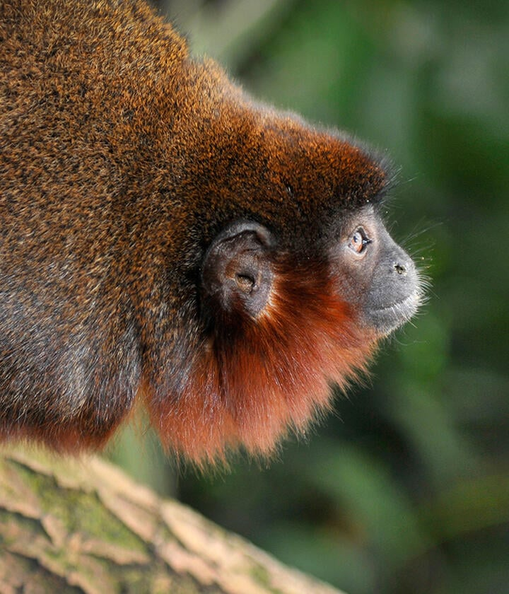

Curious Titi Monkey!

## Background

Every Saturday morning, at the same time, a primatologist goes and sits in the forest to listen for titi monkey calls, counting the number of calls they hear in a 2 hour window from 5am to 7am. Based on previous knowledge, she believes that the mean number of calls she will hear in that time is exactly 15. Let X represent the appropriate Poisson random variable of the number of calls heard in each monitoring session.

## What is the probability that she will hear more than 8 calls during any given session?

To run probability for counts like how often something is occurring in a time frame, we want to use the Poisson Distribution Model! So we know the function will be `rpois()`, `dpois()`, `ppois()`, or `qpois()`. For this question, we need `ppois()` because we want a cumulative probability of the calls occuring and we want 1-`ppois()` because we want all the probabilities more than eight, not less than.

```r
X<-8
1-ppois(q=X, lambda=15)
```

```
## [1] 0.9625535
```

So, the probability that she will hear more than 8 calls in a session is 0.96.

## What is the probability that she will hear no calls in a session?

For this one, I’m going to use `dpois()` because I want the probability of exactly 0 calls (not cumulative).

```r
X<-0
dpois(X, lambda = 15)
```

```
## [1] 3.059023e-07
```

The probability that she will hear no calls is 3.06e-07.

## What is the probability that she will hear exactly 3 calls in a session?

Same as the last question, I’m going to use `dpois()` for an exact probability.

```r
X<-3
dpois(X, lambda=15)
```

```
## [1] 0.0001720701
```

## Plot the relevant Poisson mass function over the values in range 0 ≤ x ≤ 30.

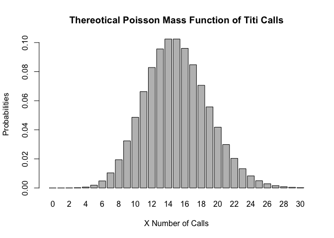

```r
pmf<-barplot(dpois(0:30, lambda = 15), names.arg = 0:30, main =  "Thereotical Poisson Mass Function of Titi Calls", xlab = "X Number of Calls", ylab = "Probabilities")
```

In this plot, you can see that the highest probability is at lambda, 15.

## Simulate 104 results from this distribution (i.e., 2 years of Saturday monitoring sessions).

```r
set.seed(923)
twoyr<-rpois(104, lambda = 15)
twoyr
```

```
##   [1] 12  9 15 14 10 16 20 19 15 11 14 20 14 13 16 13 14  9 23 20 17 10 19 13 16
##  [26] 16 12 11 14 17 14 21 16 20 12 14 10 13 11 12 13 12 13 13 18 10 19 17 10 11
##  [51] 22 13 18 15 16 19 15 12 17 11 16 32  9 23 17 13 17 23 12 14 10 21 12 15 17
##  [76] 15 11 12 13 20 20 14 16 18 15 13 15 19 17 22 12 14 23 14 15 16 19 11 19 16
## [101] 18 17 12 21
```

## Plot the simulated results using hist() and use xlim() to set the horizontal limits to be from 0 to 30.

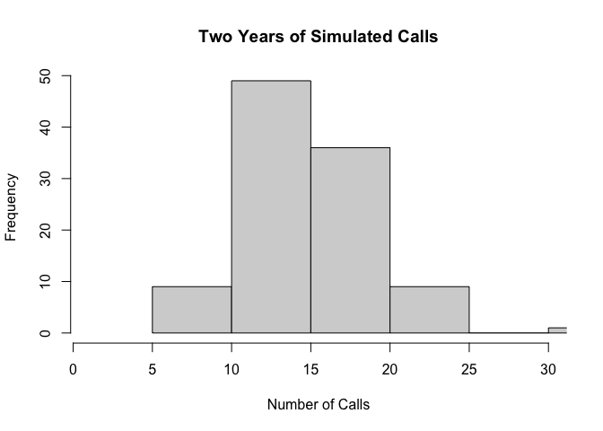

```r
hist(twoyr, xlim = c(1,30), xlab = "Number of Calls", main = "Two Years of Simulated Calls")
```

## How does your histogram compare to the shape of the probability mass function you plotted above?

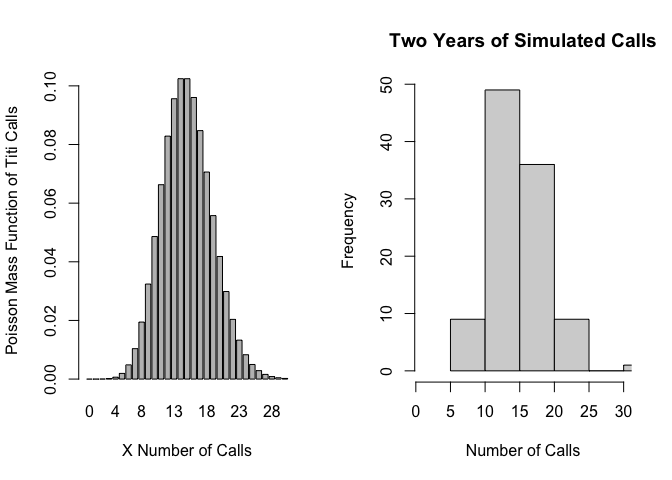

```r
par(mfrow= c(1,2))
barplot(dpois(0:30, lambda = 15), names.arg = 0:30, ylab = "Poisson Mass Function of Titi Calls", xlab = "X Number of Calls")
hist(twoyr, xlim = c(1,30), xlab = "Number of Calls", main = "Two Years of Simulated Calls")
```

## Reflection

Jimmy’s commentary was really excellent and helpful. I was so focused on making sure I understood everything, I completely forgot to provide adequate commentary of what I was doing and how. I also forgot my Titi monkey photo, which I remembered while commenting. I appreciated getting some positive feedback as well, that was reassuring. I learned a lot from looking at and running his code as well, even as simple a how to imbed a function like this (`ppois()`). The specific comments improved my code as well, I think. Very positive experience!